# Risk Factor Analysis

## Outcome Variable

**Outcome Variable:** ever_wasted

## Predictor Variables

**Intervention Variable:** nhh

**Adjustment Set:**

- arm
- W_mage
- meducyrs
- feducyrs
- W_mhtcm
- W_mwtkg
- W_mbmi
- W_nrooms
- impfloor
- impsan
- safeh20
- delta_W_mage
- delta_meducyrs
- delta_feducyrs
- delta_W_mhtcm
- delta_W_mwtkg
- delta_W_mbmi
- delta_W_nrooms
- delta_impfloor
- delta_impsan
- delta_safeh20

## Stratifying Variables

The analysis was stratified on these variable(s):

- agecat
- studyid
- country

## Data Summary

| agecat | studyid | country | nhh | ever_wasted | n_cell | n |
| --- | --- | --- | --- | --- | --- | --- |
| 0-24 months | IRC | INDIA | 3 or less | 0 | 20 | 410 |
| 0-24 months | IRC | INDIA | 3 or less | 1 | 38 | 410 |
| 0-24 months | IRC | INDIA | 4-5 | 0 | 63 | 410 |
| 0-24 months | IRC | INDIA | 4-5 | 1 | 95 | 410 |
| 0-24 months | IRC | INDIA | 6-7 | 0 | 38 | 410 |
| 0-24 months | IRC | INDIA | 6-7 | 1 | 69 | 410 |
| 0-24 months | IRC | INDIA | 8+ | 0 | 20 | 410 |
| 0-24 months | IRC | INDIA | 8+ | 1 | 67 | 410 |
| 0-24 months | LCNI-5 | MALAWI | 3 or less | 0 | 210 | 817 |
| 0-24 months | LCNI-5 | MALAWI | 3 or less | 1 | 15 | 817 |
| 0-24 months | LCNI-5 | MALAWI | 4-5 | 0 | 310 | 817 |
| 0-24 months | LCNI-5 | MALAWI | 4-5 | 1 | 30 | 817 |
| 0-24 months | LCNI-5 | MALAWI | 6-7 | 0 | 172 | 817 |
| 0-24 months | LCNI-5 | MALAWI | 6-7 | 1 | 10 | 817 |
| 0-24 months | LCNI-5 | MALAWI | 8+ | 0 | 59 | 817 |
| 0-24 months | LCNI-5 | MALAWI | 8+ | 1 | 11 | 817 |
| 0-24 months | NIH-Birth | BANGLADESH | 3 or less | 0 | 58 | 624 |
| 0-24 months | NIH-Birth | BANGLADESH | 3 or less | 1 | 57 | 624 |
| 0-24 months | NIH-Birth | BANGLADESH | 4-5 | 0 | 134 | 624 |
| 0-24 months | NIH-Birth | BANGLADESH | 4-5 | 1 | 129 | 624 |
| 0-24 months | NIH-Birth | BANGLADESH | 6-7 | 0 | 72 | 624 |
| 0-24 months | NIH-Birth | BANGLADESH | 6-7 | 1 | 69 | 624 |
| 0-24 months | NIH-Birth | BANGLADESH | 8+ | 0 | 62 | 624 |
| 0-24 months | NIH-Birth | BANGLADESH | 8+ | 1 | 43 | 624 |
| 0-24 months | NIH-Crypto | BANGLADESH | 3 or less | 0 | 75 | 758 |
| 0-24 months | NIH-Crypto | BANGLADESH | 3 or less | 1 | 39 | 758 |
| 0-24 months | NIH-Crypto | BANGLADESH | 4-5 | 0 | 224 | 758 |
| 0-24 months | NIH-Crypto | BANGLADESH | 4-5 | 1 | 118 | 758 |
| 0-24 months | NIH-Crypto | BANGLADESH | 6-7 | 0 | 120 | 758 |
| 0-24 months | NIH-Crypto | BANGLADESH | 6-7 | 1 | 58 | 758 |

[output cut: 114 more lines]

The following strata were considered:

- agecat: 0-24 months, studyid: IRC, country: INDIA
- agecat: 0-24 months, studyid: LCNI-5, country: MALAWI
- agecat: 0-24 months, studyid: NIH-Birth, country: BANGLADESH
- agecat: 0-24 months, studyid: NIH-Crypto, country: BANGLADESH
- agecat: 0-24 months, studyid: PROVIDE, country: BANGLADESH
- agecat: 0-24 months, studyid: SAS-FoodSuppl, country: INDIA
- agecat: 0-6 months, studyid: IRC, country: INDIA
- agecat: 0-6 months, studyid: LCNI-5, country: MALAWI
- agecat: 0-6 months, studyid: NIH-Birth, country: BANGLADESH
- agecat: 0-6 months, studyid: NIH-Crypto, country: BANGLADESH
- agecat: 0-6 months, studyid: PROVIDE, country: BANGLADESH
- agecat: 0-6 months, studyid: SAS-FoodSuppl, country: INDIA
- agecat: 6-24 months, studyid: IRC, country: INDIA
- agecat: 6-24 months, studyid: LCNI-5, country: MALAWI
- agecat: 6-24 months, studyid: NIH-Birth, country: BANGLADESH
- agecat: 6-24 months, studyid: NIH-Crypto, country: BANGLADESH
- agecat: 6-24 months, studyid: PROVIDE, country: BANGLADESH
- agecat: 6-24 months, studyid: SAS-FoodSuppl, country: INDIA

### Dropped Strata

Some strata were dropped due to rare outcomes:

- agecat: 0-6 months, studyid: LCNI-5, country: MALAWI
- agecat: 0-6 months, studyid: SAS-FoodSuppl, country: INDIA

## Methods Detail

We’re interested in the causal parameters $E[Y_a]$ for all values of $a \in \mathcal{A}$. These parameters represent the mean outcome if, possibly contrary to fact, we intervened to set all units to have $A=a$. Under the randomization and positivity assumptions, these are identified by the statistical parameters $\psi_a=E_W[E_{Y|A,W}(Y|A=a,W)]$. In addition, we’re interested in the mean of $Y$, $E[Y]$ under no intervention (the observed mean). We will estimate these parameters by using SuperLearner to fit the relevant likelihood factors – $E_{Y|A,W}(Y|A=a,W)$ and $p(A=a|W)$, and then updating our likelihood fit using a joint TMLE.

For unadjusted analyses ($W=\{\}$), initial likelihoods were estimated using Lrnr_glm to estimate the simple $E(Y|A)$ and Lrnr_mean to estimate $p(A)$. For adjusted analyses, a small library containing Lrnr_glmnet, Lrnr_xgboost, and Lrnr_mean was used.

Having estimated these parameters, we will then use the delta method to estimate relative risks and attributable risks relative to a prespecified baseline level of $A$.

# Results Detail

## Results Plots

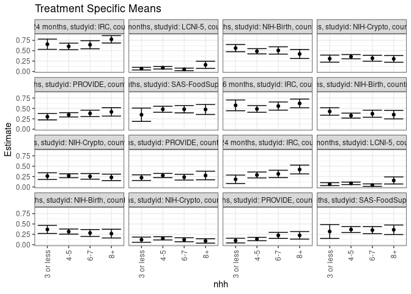

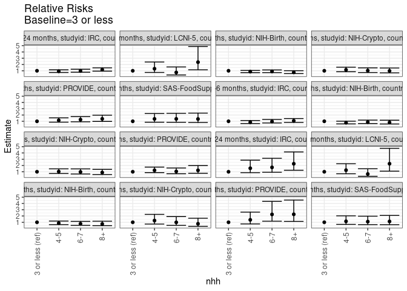

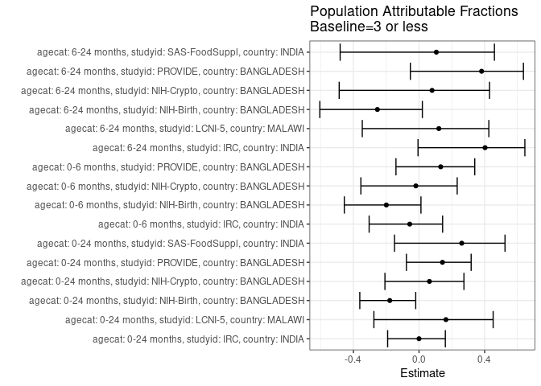

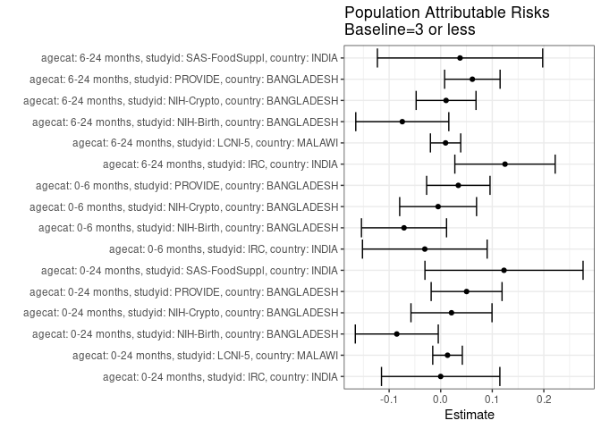

## Results Table

### Parameter: TSM

| agecat | studyid | country | intervention_level | baseline_level | estimate | ci_lower | ci_upper |
| --- | --- | --- | --- | --- | --- | --- | --- |
| 0-24 months | IRC | INDIA | 3 or less | NA | 0.6561403 | 0.5326223 | 0.7796584 |
| 0-24 months | IRC | INDIA | 4-5 | NA | 0.6039279 | 0.5258181 | 0.6820377 |
| 0-24 months | IRC | INDIA | 6-7 | NA | 0.6432654 | 0.5459758 | 0.7405550 |
| 0-24 months | IRC | INDIA | 8+ | NA | 0.7737136 | 0.6845923 | 0.8628348 |
| 0-24 months | LCNI-5 | MALAWI | 3 or less | NA | 0.0675322 | 0.0350125 | 0.1000519 |
| 0-24 months | LCNI-5 | MALAWI | 4-5 | NA | 0.0897186 | 0.0591348 | 0.1203023 |
| 0-24 months | LCNI-5 | MALAWI | 6-7 | NA | 0.0493296 | 0.0184079 | 0.0802513 |
| 0-24 months | LCNI-5 | MALAWI | 8+ | NA | 0.1604280 | 0.0748525 | 0.2460035 |
| 0-24 months | NIH-Birth | BANGLADESH | 3 or less | NA | 0.5627322 | 0.4752691 | 0.6501952 |
| 0-24 months | NIH-Birth | BANGLADESH | 4-5 | NA | 0.4866890 | 0.4241153 | 0.5492626 |
| 0-24 months | NIH-Birth | BANGLADESH | 6-7 | NA | 0.5057388 | 0.4176507 | 0.5938270 |
| 0-24 months | NIH-Birth | BANGLADESH | 8+ | NA | 0.4215416 | 0.3127722 | 0.5303110 |
| 0-24 months | NIH-Crypto | BANGLADESH | 3 or less | NA | 0.3088665 | 0.2237357 | 0.3939972 |
| 0-24 months | NIH-Crypto | BANGLADESH | 4-5 | NA | 0.3565329 | 0.3055180 | 0.4075479 |
| 0-24 months | NIH-Crypto | BANGLADESH | 6-7 | NA | 0.3176112 | 0.2465835 | 0.3886389 |
| 0-24 months | NIH-Crypto | BANGLADESH | 8+ | NA | 0.3034026 | 0.2217145 | 0.3850907 |
| 0-24 months | PROVIDE | BANGLADESH | 3 or less | NA | 0.3012040 | 0.2249343 | 0.3774737 |
| 0-24 months | PROVIDE | BANGLADESH | 4-5 | NA | 0.3470365 | 0.2949628 | 0.3991103 |
| 0-24 months | PROVIDE | BANGLADESH | 6-7 | NA | 0.3806546 | 0.3040474 | 0.4572619 |
| 0-24 months | PROVIDE | BANGLADESH | 8+ | NA | 0.4180115 | 0.3164456 | 0.5195774 |
| 0-24 months | SAS-FoodSuppl | INDIA | 3 or less | NA | 0.3485120 | 0.1882859 | 0.5087382 |
| 0-24 months | SAS-FoodSuppl | INDIA | 4-5 | NA | 0.4806364 | 0.4079699 | 0.5533029 |
| 0-24 months | SAS-FoodSuppl | INDIA | 6-7 | NA | 0.4812844 | 0.3939399 | 0.5686289 |
| 0-24 months | SAS-FoodSuppl | INDIA | 8+ | NA | 0.4754781 | 0.3550681 | 0.5958882 |
| 0-6 months | IRC | INDIA | 3 or less | NA | 0.5747313 | 0.4450298 | 0.7044329 |
| 0-6 months | IRC | INDIA | 4-5 | NA | 0.4880819 | 0.4079858 | 0.5681780 |
| 0-6 months | IRC | INDIA | 6-7 | NA | 0.5576655 | 0.4593485 | 0.6559825 |
| 0-6 months | IRC | INDIA | 8+ | NA | 0.6214438 | 0.5174678 | 0.7254198 |
| 0-6 months | NIH-Birth | BANGLADESH | 3 or less | NA | 0.4280578 | 0.3375829 | 0.5185327 |
| 0-6 months | NIH-Birth | BANGLADESH | 4-5 | NA | 0.3287421 | 0.2691883 | 0.3882959 |
| 0-6 months | NIH-Birth | BANGLADESH | 6-7 | NA | 0.3726951 | 0.2880879 | 0.4573022 |
| 0-6 months | NIH-Birth | BANGLADESH | 8+ | NA | 0.3501960 | 0.2485786 | 0.4518135 |
| 0-6 months | NIH-Crypto | BANGLADESH | 3 or less | NA | 0.2622496 | 0.1816477 | 0.3428516 |
| 0-6 months | NIH-Crypto | BANGLADESH | 4-5 | NA | 0.2705177 | 0.2235829 | 0.3174526 |
| 0-6 months | NIH-Crypto | BANGLADESH | 6-7 | NA | 0.2549280 | 0.1872993 | 0.3225566 |
| 0-6 months | NIH-Crypto | BANGLADESH | 8+ | NA | 0.2312852 | 0.1544348 | 0.3081357 |
| 0-6 months | PROVIDE | BANGLADESH | 3 or less | NA | 0.2243817 | 0.1568496 | 0.2919139 |
| 0-6 months | PROVIDE | BANGLADESH | 4-5 | NA | 0.2759837 | 0.2260127 | 0.3259547 |
| 0-6 months | PROVIDE | BANGLADESH | 6-7 | NA | 0.2357633 | 0.1665183 | 0.3050082 |
| 0-6 months | PROVIDE | BANGLADESH | 8+ | NA | 0.2764467 | 0.1730090 | 0.3798843 |
| 6-24 months | IRC | INDIA | 3 or less | NA | 0.1850344 | 0.0837053 | 0.2863634 |
| 6-24 months | IRC | INDIA | 4-5 | NA | 0.2889791 | 0.2177338 | 0.3602243 |
| 6-24 months | IRC | INDIA | 6-7 | NA | 0.3149351 | 0.2271494 | 0.4027209 |
| 6-24 months | IRC | INDIA | 8+ | NA | 0.4211473 | 0.3153230 | 0.5269715 |
| 6-24 months | LCNI-5 | MALAWI | 3 or less | NA | 0.0688073 | 0.0351851 | 0.1024296 |
| 6-24 months | LCNI-5 | MALAWI | 4-5 | NA | 0.0863095 | 0.0562642 | 0.1163549 |
| 6-24 months | LCNI-5 | MALAWI | 6-7 | NA | 0.0441989 | 0.0142371 | 0.0741607 |
| 6-24 months | LCNI-5 | MALAWI | 8+ | NA | 0.1571429 | 0.0718342 | 0.2424516 |
| 6-24 months | NIH-Birth | BANGLADESH | 3 or less | NA | 0.3678232 | 0.2699722 | 0.4656741 |
| 6-24 months | NIH-Birth | BANGLADESH | 4-5 | NA | 0.3166312 | 0.2550666 | 0.3781958 |
| 6-24 months | NIH-Birth | BANGLADESH | 6-7 | NA | 0.2821155 | 0.1986425 | 0.3655885 |
| 6-24 months | NIH-Birth | BANGLADESH | 8+ | NA | 0.2674083 | 0.1620041 | 0.3728124 |
| 6-24 months | NIH-Crypto | BANGLADESH | 3 or less | NA | 0.1210604 | 0.0585994 | 0.1835214 |
| 6-24 months | NIH-Crypto | BANGLADESH | 4-5 | NA | 0.1539516 | 0.1148099 | 0.1930932 |
| 6-24 months | NIH-Crypto | BANGLADESH | 6-7 | NA | 0.1197796 | 0.0714670 | 0.1680921 |
| 6-24 months | NIH-Crypto | BANGLADESH | 8+ | NA | 0.0916686 | 0.0386125 | 0.1447246 |
| 6-24 months | PROVIDE | BANGLADESH | 3 or less | NA | 0.0995712 | 0.0431699 | 0.1559726 |
| 6-24 months | PROVIDE | BANGLADESH | 4-5 | NA | 0.1378518 | 0.0978503 | 0.1778533 |
| 6-24 months | PROVIDE | BANGLADESH | 6-7 | NA | 0.2244881 | 0.1515986 | 0.2973776 |
| 6-24 months | PROVIDE | BANGLADESH | 8+ | NA | 0.2260557 | 0.1358578 | 0.3162537 |
| 6-24 months | SAS-FoodSuppl | INDIA | 3 or less | NA | 0.3181885 | 0.1506419 | 0.4857351 |
| 6-24 months | SAS-FoodSuppl | INDIA | 4-5 | NA | 0.3663160 | 0.2946226 | 0.4380094 |
| 6-24 months | SAS-FoodSuppl | INDIA | 6-7 | NA | 0.3514285 | 0.2659872 | 0.4368698 |
| 6-24 months | SAS-FoodSuppl | INDIA | 8+ | NA | 0.3601761 | 0.2456342 | 0.4747179 |

### Parameter: E(Y)

| agecat | studyid | country | intervention_level | baseline_level | estimate | ci_lower | ci_upper |
| --- | --- | --- | --- | --- | --- | --- | --- |
| 0-24 months | IRC | INDIA | NA | NA | 0.6560976 | 0.6100625 | 0.7021326 |
| 0-24 months | LCNI-5 | MALAWI | NA | NA | 0.0807834 | 0.0620863 | 0.0994804 |
| 0-24 months | NIH-Birth | BANGLADESH | NA | NA | 0.4775641 | 0.4383415 | 0.5167867 |
| 0-24 months | NIH-Crypto | BANGLADESH | NA | NA | 0.3298153 | 0.2963239 | 0.3633067 |
| 0-24 months | PROVIDE | BANGLADESH | NA | NA | 0.3514286 | 0.3160364 | 0.3868207 |
| 0-24 months | SAS-FoodSuppl | INDIA | NA | NA | 0.4712919 | 0.4233811 | 0.5192026 |
| 0-6 months | IRC | INDIA | NA | NA | 0.5439024 | 0.4956326 | 0.5921723 |
| 0-6 months | NIH-Birth | BANGLADESH | NA | NA | 0.3569132 | 0.3192325 | 0.3945938 |
| 0-6 months | NIH-Crypto | BANGLADESH | NA | NA | 0.2572559 | 0.2261171 | 0.2883948 |
| 0-6 months | PROVIDE | BANGLADESH | NA | NA | 0.2585714 | 0.2261125 | 0.2910304 |
| 6-24 months | IRC | INDIA | NA | NA | 0.3097561 | 0.2649438 | 0.3545684 |
| 6-24 months | LCNI-5 | MALAWI | NA | NA | 0.0782609 | 0.0596958 | 0.0968259 |
| 6-24 months | NIH-Birth | BANGLADESH | NA | NA | 0.2933579 | 0.2549918 | 0.3317241 |
| 6-24 months | NIH-Crypto | BANGLADESH | NA | NA | 0.1315068 | 0.1069744 | 0.1560393 |
| 6-24 months | PROVIDE | BANGLADESH | NA | NA | 0.1609756 | 0.1319065 | 0.1900447 |
| 6-24 months | SAS-FoodSuppl | INDIA | NA | NA | 0.3557214 | 0.3088651 | 0.4025777 |

### Parameter: RR

| agecat | studyid | country | intervention_level | baseline_level | estimate | ci_lower | ci_upper |
| --- | --- | --- | --- | --- | --- | --- | --- |
| 0-24 months | IRC | INDIA | 3 or less | 3 or less | 1.0000000 | 1.0000000 | 1.000000 |
| 0-24 months | IRC | INDIA | 4-5 | 3 or less | 0.9204249 | 0.7324204 | 1.156688 |
| 0-24 months | IRC | INDIA | 6-7 | 3 or less | 0.9803778 | 0.7700113 | 1.248216 |
| 0-24 months | IRC | INDIA | 8+ | 3 or less | 1.1791891 | 0.9454567 | 1.470704 |
| 0-24 months | LCNI-5 | MALAWI | 3 or less | 3 or less | 1.0000000 | 1.0000000 | 1.000000 |
| 0-24 months | LCNI-5 | MALAWI | 4-5 | 3 or less | 1.3285296 | 0.7367555 | 2.395626 |
| 0-24 months | LCNI-5 | MALAWI | 6-7 | 3 or less | 0.7304600 | 0.3314374 | 1.609872 |
| 0-24 months | LCNI-5 | MALAWI | 8+ | 3 or less | 2.3755771 | 1.1582225 | 4.872437 |
| 0-24 months | NIH-Birth | BANGLADESH | 3 or less | 3 or less | 1.0000000 | 1.0000000 | 1.000000 |
| 0-24 months | NIH-Birth | BANGLADESH | 4-5 | 3 or less | 0.8648679 | 0.7070968 | 1.057842 |
| 0-24 months | NIH-Birth | BANGLADESH | 6-7 | 3 or less | 0.8987204 | 0.7115233 | 1.135168 |
| 0-24 months | NIH-Birth | BANGLADESH | 8+ | 3 or less | 0.7490981 | 0.5540604 | 1.012792 |
| 0-24 months | NIH-Crypto | BANGLADESH | 3 or less | 3 or less | 1.0000000 | 1.0000000 | 1.000000 |
| 0-24 months | NIH-Crypto | BANGLADESH | 4-5 | 3 or less | 1.1543272 | 0.8467359 | 1.573656 |
| 0-24 months | NIH-Crypto | BANGLADESH | 6-7 | 3 or less | 1.0283123 | 0.7213663 | 1.465866 |
| 0-24 months | NIH-Crypto | BANGLADESH | 8+ | 3 or less | 0.9823101 | 0.6687183 | 1.442959 |
| 0-24 months | PROVIDE | BANGLADESH | 3 or less | 3 or less | 1.0000000 | 1.0000000 | 1.000000 |
| 0-24 months | PROVIDE | BANGLADESH | 4-5 | 3 or less | 1.1521645 | 0.8583786 | 1.546501 |
| 0-24 months | PROVIDE | BANGLADESH | 6-7 | 3 or less | 1.2637769 | 0.9154360 | 1.744668 |
| 0-24 months | PROVIDE | BANGLADESH | 8+ | 3 or less | 1.3878022 | 0.9779087 | 1.969504 |
| 0-24 months | SAS-FoodSuppl | INDIA | 3 or less | 3 or less | 1.0000000 | 1.0000000 | 1.000000 |
| 0-24 months | SAS-FoodSuppl | INDIA | 4-5 | 3 or less | 1.3791098 | 0.8499471 | 2.237720 |
| 0-24 months | SAS-FoodSuppl | INDIA | 6-7 | 3 or less | 1.3809691 | 0.8423926 | 2.263880 |
| 0-24 months | SAS-FoodSuppl | INDIA | 8+ | 3 or less | 1.3643090 | 0.8077764 | 2.304275 |
| 0-6 months | IRC | INDIA | 3 or less | 3 or less | 1.0000000 | 1.0000000 | 1.000000 |
| 0-6 months | IRC | INDIA | 4-5 | 3 or less | 0.8492348 | 0.6422796 | 1.122875 |
| 0-6 months | IRC | INDIA | 6-7 | 3 or less | 0.9703064 | 0.7286022 | 1.292193 |
| 0-6 months | IRC | INDIA | 8+ | 3 or less | 1.0812771 | 0.8161714 | 1.432493 |
| 0-6 months | NIH-Birth | BANGLADESH | 3 or less | 3 or less | 1.0000000 | 1.0000000 | 1.000000 |
| 0-6 months | NIH-Birth | BANGLADESH | 4-5 | 3 or less | 0.7679853 | 0.5812221 | 1.014761 |
| 0-6 months | NIH-Birth | BANGLADESH | 6-7 | 3 or less | 0.8706652 | 0.6384135 | 1.187409 |
| 0-6 months | NIH-Birth | BANGLADESH | 8+ | 3 or less | 0.8181045 | 0.5712495 | 1.171633 |
| 0-6 months | NIH-Crypto | BANGLADESH | 3 or less | 3 or less | 1.0000000 | 1.0000000 | 1.000000 |
| 0-6 months | NIH-Crypto | BANGLADESH | 4-5 | 3 or less | 1.0315276 | 0.7247316 | 1.468198 |
| 0-6 months | NIH-Crypto | BANGLADESH | 6-7 | 3 or less | 0.9720813 | 0.6474691 | 1.459439 |
| 0-6 months | NIH-Crypto | BANGLADESH | 8+ | 3 or less | 0.8819278 | 0.5607606 | 1.387039 |
| 0-6 months | PROVIDE | BANGLADESH | 3 or less | 3 or less | 1.0000000 | 1.0000000 | 1.000000 |
| 0-6 months | PROVIDE | BANGLADESH | 4-5 | 3 or less | 1.2299738 | 0.8656633 | 1.747603 |
| 0-6 months | PROVIDE | BANGLADESH | 6-7 | 3 or less | 1.0507239 | 0.6898475 | 1.600384 |
| 0-6 months | PROVIDE | BANGLADESH | 8+ | 3 or less | 1.2320373 | 0.7621483 | 1.991628 |
| 6-24 months | IRC | INDIA | 3 or less | 3 or less | 1.0000000 | 1.0000000 | 1.000000 |
| 6-24 months | IRC | INDIA | 4-5 | 3 or less | 1.5617590 | 0.8560311 | 2.849302 |
| 6-24 months | IRC | INDIA | 6-7 | 3 or less | 1.7020359 | 0.9201103 | 3.148455 |
| 6-24 months | IRC | INDIA | 8+ | 3 or less | 2.2760489 | 1.2445453 | 4.162483 |
| 6-24 months | LCNI-5 | MALAWI | 3 or less | 3 or less | 1.0000000 | 1.0000000 | 1.000000 |
| 6-24 months | LCNI-5 | MALAWI | 4-5 | 3 or less | 1.2543651 | 0.6884364 | 2.285515 |
| 6-24 months | LCNI-5 | MALAWI | 6-7 | 3 or less | 0.6423573 | 0.2785228 | 1.481469 |
| 6-24 months | LCNI-5 | MALAWI | 8+ | 3 or less | 2.2838095 | 1.1001482 | 4.740985 |
| 6-24 months | NIH-Birth | BANGLADESH | 3 or less | 3 or less | 1.0000000 | 1.0000000 | 1.000000 |
| 6-24 months | NIH-Birth | BANGLADESH | 4-5 | 3 or less | 0.8608244 | 0.6200427 | 1.195109 |
| 6-24 months | NIH-Birth | BANGLADESH | 6-7 | 3 or less | 0.7669868 | 0.5151756 | 1.141880 |
| 6-24 months | NIH-Birth | BANGLADESH | 8+ | 3 or less | 0.7270023 | 0.4513108 | 1.171105 |
| 6-24 months | NIH-Crypto | BANGLADESH | 3 or less | 3 or less | 1.0000000 | 1.0000000 | 1.000000 |
| 6-24 months | NIH-Crypto | BANGLADESH | 4-5 | 3 or less | 1.2716921 | 0.7154452 | 2.260412 |
| 6-24 months | NIH-Crypto | BANGLADESH | 6-7 | 3 or less | 0.9894197 | 0.5139946 | 1.904595 |
| 6-24 months | NIH-Crypto | BANGLADESH | 8+ | 3 or less | 0.7572133 | 0.3487423 | 1.644113 |
| 6-24 months | PROVIDE | BANGLADESH | 3 or less | 3 or less | 1.0000000 | 1.0000000 | 1.000000 |
| 6-24 months | PROVIDE | BANGLADESH | 4-5 | 3 or less | 1.3844540 | 0.7326888 | 2.615998 |
| 6-24 months | PROVIDE | BANGLADESH | 6-7 | 3 or less | 2.2545476 | 1.1732597 | 4.332362 |
| 6-24 months | PROVIDE | BANGLADESH | 8+ | 3 or less | 2.2702913 | 1.1357743 | 4.538069 |
| 6-24 months | SAS-FoodSuppl | INDIA | 3 or less | 3 or less | 1.0000000 | 1.0000000 | 1.000000 |
| 6-24 months | SAS-FoodSuppl | INDIA | 4-5 | 3 or less | 1.1512546 | 0.6555956 | 2.021654 |
| 6-24 months | SAS-FoodSuppl | INDIA | 6-7 | 3 or less | 1.1044662 | 0.6182606 | 1.973028 |
| 6-24 months | SAS-FoodSuppl | INDIA | 8+ | 3 or less | 1.1319581 | 0.6113999 | 2.095730 |

### Parameter: PAR

| agecat | studyid | country | intervention_level | baseline_level | estimate | ci_lower | ci_upper |
| --- | --- | --- | --- | --- | --- | --- | --- |
| 0-24 months | IRC | INDIA | 3 or less | NA | -0.0000428 | -0.1148318 | 0.1147462 |
| 0-24 months | LCNI-5 | MALAWI | 3 or less | NA | 0.0132511 | -0.0154275 | 0.0419297 |
| 0-24 months | NIH-Birth | BANGLADESH | 3 or less | NA | -0.0851681 | -0.1656089 | -0.0047272 |
| 0-24 months | NIH-Crypto | BANGLADESH | 3 or less | NA | 0.0209489 | -0.0576335 | 0.0995312 |
| 0-24 months | PROVIDE | BANGLADESH | 3 or less | NA | 0.0502246 | -0.0185065 | 0.1189557 |
| 0-24 months | SAS-FoodSuppl | INDIA | 3 or less | NA | 0.1227798 | -0.0305396 | 0.2760993 |
| 0-6 months | IRC | INDIA | 3 or less | NA | -0.0308289 | -0.1517229 | 0.0900651 |
| 0-6 months | NIH-Birth | BANGLADESH | 3 or less | NA | -0.0711447 | -0.1536379 | 0.0113486 |
| 0-6 months | NIH-Crypto | BANGLADESH | 3 or less | NA | -0.0049937 | -0.0795169 | 0.0695295 |
| 0-6 months | PROVIDE | BANGLADESH | 3 or less | NA | 0.0341897 | -0.0272827 | 0.0956621 |
| 6-24 months | IRC | INDIA | 3 or less | NA | 0.1247217 | 0.0274345 | 0.2220089 |
| 6-24 months | LCNI-5 | MALAWI | 3 or less | NA | 0.0094535 | -0.0199207 | 0.0388278 |
| 6-24 months | NIH-Birth | BANGLADESH | 3 or less | NA | -0.0744652 | -0.1646694 | 0.0157389 |
| 6-24 months | NIH-Crypto | BANGLADESH | 3 or less | NA | 0.0104464 | -0.0476042 | 0.0684970 |
| 6-24 months | PROVIDE | BANGLADESH | 3 or less | NA | 0.0614044 | 0.0076115 | 0.1151972 |
| 6-24 months | SAS-FoodSuppl | INDIA | 3 or less | NA | 0.0375329 | -0.1227426 | 0.1978084 |

### Parameter: PAF

| agecat | studyid | country | intervention_level | baseline_level | estimate | ci_lower | ci_upper |
| --- | --- | --- | --- | --- | --- | --- | --- |
| 0-24 months | IRC | INDIA | 3 or less | NA | -0.0000652 | -0.1912594 | 0.1604428 |
| 0-24 months | LCNI-5 | MALAWI | 3 or less | NA | 0.1640328 | -0.2751599 | 0.4519581 |
| 0-24 months | NIH-Birth | BANGLADESH | 3 or less | NA | -0.1783385 | -0.3611029 | -0.0201151 |
| 0-24 months | NIH-Crypto | BANGLADESH | 3 or less | NA | 0.0635169 | -0.2078311 | 0.2739046 |
| 0-24 months | PROVIDE | BANGLADESH | 3 or less | NA | 0.1429155 | -0.0768459 | 0.3178283 |
| 0-24 months | SAS-FoodSuppl | INDIA | 3 or less | NA | 0.2605176 | -0.1494238 | 0.5242536 |
| 0-6 months | IRC | INDIA | 3 or less | NA | -0.0566809 | -0.3041943 | 0.1438587 |
| 0-6 months | NIH-Birth | BANGLADESH | 3 or less | NA | -0.1993332 | -0.4555568 | 0.0117870 |
| 0-6 months | NIH-Crypto | BANGLADESH | 3 or less | NA | -0.0194114 | -0.3544791 | 0.2327680 |
| 0-6 months | PROVIDE | BANGLADESH | 3 or less | NA | 0.1322253 | -0.1405428 | 0.3397592 |
| 6-24 months | IRC | INDIA | 3 or less | NA | 0.4026450 | -0.0060974 | 0.6453295 |
| 6-24 months | LCNI-5 | MALAWI | 3 or less | NA | 0.1207951 | -0.3459615 | 0.4256884 |
| 6-24 months | NIH-Birth | BANGLADESH | 3 or less | NA | -0.2538374 | -0.6048027 | 0.0203728 |
| 6-24 months | NIH-Crypto | BANGLADESH | 3 or less | NA | 0.0794364 | -0.4867925 | 0.4300231 |
| 6-24 months | PROVIDE | BANGLADESH | 3 or less | NA | 0.3814514 | -0.0527679 | 0.6365748 |
| 6-24 months | SAS-FoodSuppl | INDIA | 3 or less | NA | 0.1055120 | -0.4808891 | 0.4597105 |